# Speech Recognition : Google Speech To Text - Text To Speech API

**Internal Training Algoritma**

**Fafilia Masrofin**

## Speech Recognition

Biometrik merupakan salah satu metode atau cara untuk mengenali manusia berdasarkan satu atau lebih ciri-ciri fisik atau tingkah laku yang unik. Salah satu biometrik yang dapat digunakan adalah suara melalui pengenalan suara atau speech recognition. Suara atau secara luas kita sebut ucapan merupakan bentuk komunikasi paling alami bagi manusia.

Speech Recognition merupakan sistem yang digunakan untuk mengenali perintah kata dari suara manusia dan kemudian diterjemahkan menjadi suatu data yang dimengerti oleh komputer. Inputan berupa suara yang ditangkap oleh perangkat audio yang akan diterjemahkan/dikonversi dari sinyal akustik menjadi sebuah keluaran berupa teks. Pada saat ini, sistem ini digunakan untuk menggantikan peranan input dari keyboard ataupun mouse. Kata-kata yang ditangkap dan dikenali bisa jadi sebagai hasil akhir untuk sebuah aplikasi seperti command & control, penginputan data, dan persiapan dokumen.

### Ide dasar Speech Recognition

Komunikasi antar manusia tidak akan terjadi tanpa sebuah ucapan. Saat berbicara kita melakukan sintesis ucapan, pengenalan ucapan, dan pemahaman ucapan. Ketika kita berbicara tentang ucapan, maka kita tidak bisa menyebutkan bahwa konteks dari sebuah ucapan adalah hal yang sederhana. Dalam sebuah ucapan, konteks penting yang terjadi adalah di mana kita berbicara, mengapa kita berbicara, siapa audiens kita, dan apa yang menjadi tujuan kita itu adalah suatu yang penting. Cara manusia berbicarapun sangat bervariasi. Singkatnya, sebuah ucapan itu sangatlah kompleks dan rumit. Pada sebuah ucapan, manusia mencoba untuk menyampaikan pemikiran dan pengalamannya melalui suara dan bahasa sehingga dapat dimengerti oleh manusia lainnya. Komunikasi melalui sebuah ucapan dapat dirumuskan dan digambarkan sebagai berikut:

1. Pembicara merumuskan ucapannya pada sebuah kata
2. Pembicara menghasilkan suara dari pita suara dan sistem wicara
3. Suara ditransmisikan melalui gelombang akustik di udara ke telinga pendengar sebagai getaran
4. Suara ditransmisikan ke otak pendengar melalui saraf pendengaran
5. Getaran-getaran itu diubah menjadi "bahasa" di otak seorang pendengar.
6. Otak memahami/mengekstrak makna dari suara tersebut.

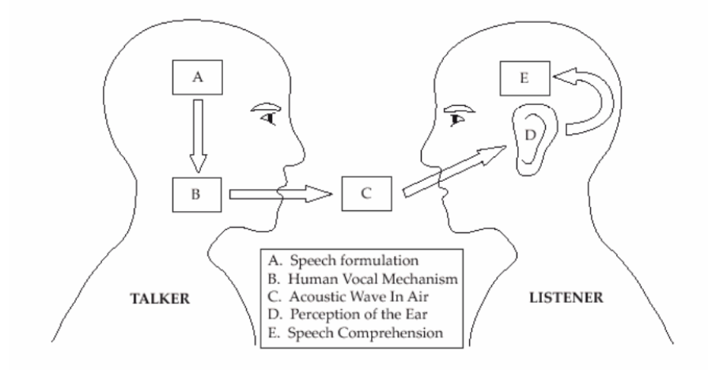

```python
from IPython.display import Image
Image("communicate.png", width=500)
```

Tujuan utama dari Automation Speech Recognition (ASR) adalah membangun sistem yang dapat mensimulasikan bagaimana cara mendengar manusia, yaitu ia dapat memahami bahasa yang diucapkan dan merespons dengan kata lain bahwa sistem dapat bereaksi dengan tepat terhadap kata-kata yang diucapkan dan mengonversi ucapan ke media lain seperti teks.

### Jenis-jenis pengenalan ucapan

Berdasarkan kemampuan dalam mengenal kata yang diucapkan, terdapat 5 jenis pengenalan kata, yaitu:

- Isolated Words:

Proses pengidentifikasian kata yang hanya dapat mengenal kata yang diucapkan jika kata tersebut memiliki jeda waktu pengucapan antar kata

- Connected Words:

Proses pengidentifikasian kata yang mirip dengan kata-kata terisolasi, namun membutuhkan jeda waktu pengucapan antar kata yang lebih singkat

- Continuous Speech:

Proses pengidentifikasian kata yang sudah lebih maju karena dapat mengenal kata-kata yang diucapkan secara berkesinambungan dengan jeda waktu yang sangat sedikit atau tanpa jeda waktu. Proses pengenalan suara ini sangat rumit karena membutuhkan metode khusus untuk membedakan kata-kata yang diucapkan tanpa jeda waktu. Pengguna perangkat ini dapat mengucapkan kata-kata secara natural

- Spontaneous Speech:

Proses pengidentifikasian kata yang dapat mengenal kata-kata yang diucapkan secara spontan tanpa jeda waktu antar kata

- Voice Verification/Identification:

Proses pengidentifikasian kata yang tidak hanya mampu mengenal kata, namun juga mengidentifikasi siapa yang berbicara.

### Proses pengenalan suara/ujaran

1. Skema Utama Speech Recognition

   Komponen utama dalam sistem pengenalan suara :
   - Penerimaan data input : Ketika kita berbicara, kita menghasilkan getaran di udara. Getaran tersebut membentuk sebuah siynal yang selanjutnya kita sebut sebagai sinyal analog. Suara yang kita ucapkan kemudian diterima oleh device input yang berupa mikrofon. Mikrofon inilah yang selanjutnya menangkap signal analog kemudian meneruskannya melalui sinyal listrik dan mengubahnya menjadi sinyal digital yang dapat dibaca oleh komputer. Untuk dapat mengubah sinyal dari analog ke digital dibutuhkan sebuah converter yang disebut dengan Analog to Digital Converter(ADC).ADC akan mengambil sample dari suara kita yang berupa gelombang pengukuran suara secara tepat dan berkala.
   - Ekstraksi fitur (feature extraction): proses mengidentifikasi bagian-bagian dari input yang mengandung ucapan dan kemudian mengubah bagian-bagian itu menjadi sebuah urutan-urutan atau yang dikenal sebagai parameter akustik.
   - Data / korpus untuk pelatihan dan pengujian: Basis data ini adalah kumpulan ucapan yang direkam. Korpus ini harus cukup besar dan cukup relevan untuk mencakup keragaman bicara.
   - Pemodelan akustik: Model akustik mengambil bentuk gelombang bicara dan memecahnya menjadi fragmen kecil dan memprediksi fonem yang paling mungkin dalam sebuah ucapan.
   - Pemodelan pelafalan: Model pelafalan mengeluarkan suara dan mengikatnya bersama untuk membentuk kata(mengaitkan kata dengan representasi fonetisnya)
   - Pemodelan bahasa: Model bahasa mengambil kata-kata dan mengikatnya bersama-sama untuk membentuk kalimat, yaitu memprediksi urutan kata yang paling mungkin (atau string teks) di antara beberapa set string teks.
   - Decoder : menggabungkan prediksi model akustik dan bahasa dan menghasilkan string teks yang paling mungkin untuk input file pidato yang diberikan
2. Tahap Blok Speech Recognition dengan HMM
   - Tahap feature extraction: Pemfilteran sinyal suara dan mengubah sinyal suara analog ke digital. Ekstraksi fitur digunakan dalam fase pelatihan dan pengenalan. Tujuan utama Ekstraksi Fitur adalah untuk menyederhanakan pengenalan dengan meringkas sejumlah besar data ucapan tanpa kehilangan sifat akustik yang mendefinisikan ucapan tersebut. Ekstraksi fitur terdiri dari langkah-langkah berikut:
     - Frame Blocking : Sebuah investigasi menunjukkan bahwa karakteristik sinyal wicara tetap diam dalam periode waktu yang cukup singkat (quasi-stationary). Untuk alasan tersebut, sinyal ucapan diproses dalam interval waktu singkat dan terbagi menjadi bingkai(frame) dengan ukuran umumnya antara 30 dan 100 miliseconds. Setiap frame tumpang tindih dengan frame sebelumnya dengan ukuran yang telah ditentukan. Tujuan dari skema yang tumpang tindih adalah untuk memperlancar transisi dari frame ke frame.
     - Windowing : Langkah kedua adalah windowing. Hal ini dilakukan untuk menghilangkan diskontinuitas pada tepi bingkai. Jika fungsi windowing didefinisikan sebagai w (n), 0 <n <N-1 di mana N adalah jumlah sampel di setiap frame, sinyal yang dihasilkan adalah y (n) = x (n) w (n). Metode umum yang sering digunakan adalah Hamming Windows.
     - FFT (Fast Fourier Transform): Langkah selanjutnya adalah mengambil Fast Fourier Transform dari setiap frame. Transformasi ini mengubah domain dari waktu ke frekuensi.
     - Mel-Frequency Wrapping : Sinyal untuk setiap frame dilewatkan melalui filter pass band Mel-Scale untuk meniru telinga manusia
     - Cepstrum (Mel Frequency Cepstral Coefficients): Pada langkah terakhir, dilakukan inverse terhadap frame Fourier untuk membawa mereka kembali ke domain waktu menggunakan Discrete Cosine Transform yang dirumuskan dengan:

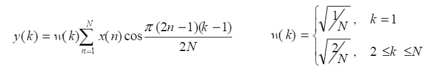

```python
Image("math.png", width=400)
```

dimana: x: sinyal asli, y: Hasil sinyal Discrete Cosine Transformed , N: jumlah sample

- Tahap tugas pemodelan: Untuk pemodelan dibuatkan suatu model HMM dari data-data yang berupa sample ucapan dari sebuah kata (berupa data digital). Setelah dilakukan segmentasi, bagian-bagian dari matriks MFCC yang sesuai dengan masing-masing fonem digunakan dalam konstruksi model HMM. Misalnya, dari MFCC kata "mereka", kita mendapatkan satu model untuk "m", "r", "k", "a", dan dua model untuk "e". Selama melatih beberapa kata, ini memungkinkan untuk membuat model fonem yang sama secara berulang. Pada kasus ini, model fonem diberi nama seperti “_e_1”, “_e_2”, “_e_15”, dan seterusnya.
- Tahap sistem pengenalan HMM: Pada tahap ini, ucapan yang tidak dikenal harus diidentifikasi sebagai kata dalam bahasa Indonesia (contoh kasus adalah kata "mereka") menggunakan model fonem yang diperoleh pada tahap penerimaan ucapan. Tahap pengenalan ini dapat diartikan sebagai proses pelatihan.
1. Proses Pencocokan Pola Suara Karena pelatihan dilakukan pada tingkat fonem, maka pengenalan model HMM juga harus dilakukan pada level yang sama. Saat melakukan pelatihan, panjang fonem terkecil dari semua fonem disimpan dalam sebuah parameter. Pada tahap pencocokan ini, ucapan yang tidak dikenal dibagi menjadi bagian-bagian yang lebih kecil dari nilai parameter yang tersimpan agar tidak setiap fonemnya dapat dikenali tanpa terlewat satupun. Panjang pemisahan minimum paling optimal yang ditemukan oleh sebuah eksperimen adalah sekitar setengah dari nilai parameter yang disimpan.

   Setelah dilakukan pemisahan pada setiap bagian dari ucapan, pencarian HMM Viterbi dibuat dengan vektor fitur yang diekstraksi dari bagian itu.

Secara umum, speech recognition memproses sinyal suara yang masuk dan menyimpannya dalam bentuk digital. Hasil proses digitalisasi tersebut kemudian dikonversi dalam bentuk spektrum suara yang akan dianalisa dengan membandingkannya dengan template suara pada database sistem. Sebelumnya, data suara masukan dipilah-pilah dan diproses satu per satu berdasarkan urutannya. Pemilihan ini dilakukan agar proses analisis dapat dilakukan secara paralel.

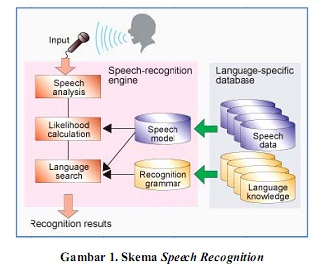

```python
from IPython.display import Image
Image("speech-recognition.jpg", width=500)
```

## Speech to Text (STT)

Pada dasarnya, cara kerja STT adalah mengubah inputan yang berupa tuturan kata (speech) audio menjadi teks yang telah tersimpan di sebuah database. Contoh sistem yang paling umum sering ditemui adalah seperti Siri yang ada pada Apple atau Cortana pada Windows, atau Google Voice yang ada pada Android. Cara kerja sederhana dari Speech to Text dapat dilihat pada gambar di bawah ini:

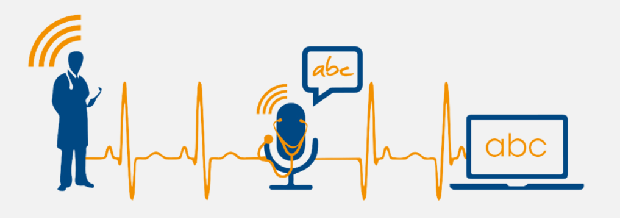

```python
from IPython.display import Image
Image("TTS and SST.png", width=800)
```

Untuk dapat menggunakan STT di python, hal yang perlu diperhatikan adalah sebagai berikut:

- Python dengan versi 2.6, 2.7 atau 3.+
- library SpeechRecognition Cara install menggunakan perintah `pip install SpeechRecognition` pada Anaconda Prompt.
- library PyAudio Cara install menggunakan perintah `pip install PyAudio` pada Anaconda Prompt. Jika terdapat error saat melakukan install library ini, Anda dapat melihat penyelesaian errornya di https://stackoverflow.com/questions/53866104/pyaudio-failed-to-install-windows-10. Di luar OS Windows bisa dilihat cara install di https://pypi.org/project/SpeechRecognition/.
- Google API Client Library for Python Cara install menggunakan perintah `pip install google-api-python-client` pada Anaconda Prompt
- Set bahasa sesuai kebutuhan yang akan di rekognisi. Pada latihan kali ini, kita akan menggunakan Bahasa Indonesia.
- Microphone sebagai alat input tuturan kata.

### Contoh Speech to Text Sederhana

```python
#Library yang dibutuhkan untuk menjalankan Speech to Text
import speech_recognition as sr
import pyaudio
import sys, os
```

```python
r = sr.Recognizer()
with sr.Microphone() as source:
    r.pause_threshold = 1
    # listen for 1 second to calibrate the energy threshold for ambient noise levels
    r.adjust_for_ambient_noise(source)
    while True:
        print("Tolong katakan sesuatu!")
        audio = r.listen(source)
        try:
            get_text = r.recognize_google(audio, language = 'id-ID').lower()
            print('Kamu bilang: ' + get_text + '\n')
            if(get_text == "keluar"):
                print("Oke, sampai ketemu lagi bosku!")
                sys.exit()
        except sr.UnknownValueError:
            print("Aku tidak paham dengan yang kamu katakan!\n")
```

```
Tolong katakan sesuatu!
Kamu bilang: algoritma data science indonesia

Tolong katakan sesuatu!
Kamu bilang: keluar

Oke, sampai ketemu lagi bosku!
```

```
An exception has occurred, use %tb to see the full traceback.

SystemExit
```

## Text to Speech(TTS)

Text to Speech adalah sebuah sistem yang dapat mengubah teks menjadi audiovisual yang dapat di dengarkan. Teks tersebut diubah menjadi ucapan secara otomatis melalui fonetisasi (penyusunan fonem-fonem untuk membentuk ucapan). Sebuah sistem TTS dapat mengucapkan kata apapun, sebab kosa katanya tidak terbatas. Contoh website yang menyediakan TTS adalah www.naturalreaders.com, namun untuk Bahasa Indonesia belum tersedia.

Untuk dapat mengimplementasikan ke dalam python maka diperlukan library GTTS. Library ini akan membuat sebuah file mp3 dari text menggunakan Google TTS. Berikut langkah dan tahapannya:

- Dibutuhkan library: gTTS, sys, os
- Untuk dapat memperdengarkan file mp3, maka pada direktori file harus tersedia file mpg123.exe (sudah tersedia pada folder internal training.

```python
from gtts import gTTS
import sys, os
```

```python
text = 'PT. Algoritma Data Indonesia (Algoritma Data Science Education Center) resmi menandatangani kesepakatan dengan Ngee Ann Polytechnic, Singapore.'
#testime = tes.strftime('%H:%M:%S')
tts = gTTS(text, lang='id')
tts.save('audio.mp3')
os.system("mpg123 audio.mp3")
```

```
0
```

```python
# Buat ke dalam fungsi yang akan membaca text
def speech_out(text):
    tts = gTTS(text, lang='id')
    tts.save('audio.mp3')
    os.system("mpg123 audio.mp3")
```

## Aplikasi Sederhana JARVIS

[figure not shown]

```python
from IPython.display import Image
Image("jarvis.png",width=900)
```

Just A Rather Very Intelligent System adalah sistem komputer antarmuka yang menggunakan bahasa alami Tony Stark.

Pada latihan kali ini, kita akan membuat sebuah program JARVIS sederhanda dengan memanfaatkan Speech Recognition. Pada kode di bawah ini diberikan 2 cara untuk mengakses/memanggil sebuah aplikasi (melalui pengenalan ucapan yang kemudian akan di proses menjadi sebuah command/perintah). Cara yang pertama, kita akan membuat sistem operasi untuk mencari sendiri program/aplikasi yang akan dijalankan berdasarkan konversi suara yang di ucapkan. Cara yang ke dua adalah dengan melakukan setting path aplikasi yang nantinya akan dipanggil berdasarkan konversi suara yang diucapakan.

```python
# Import library Speech Recognition dan pendukungnya.
import speech_recognition as sr
import pyaudio
import sys, os
from gtts import gTTS
import subprocess
import datetime
```

```python
# Ambil Bulan
bulan = ["Januari","Februari","Maret","April","Mei","Juni","Juli","Agustus","September","Oktober","November","Desember"]

# Buat ke dalam fungsi yang akan membaca text
def speech_out(text):
    tts = gTTS(text, lang='id')
    tts.save('audio.mp3')
    os.system("mpg123 audio.mp3")

speech_out("halo Tuanku apakah ada yang bisa dibantu?")
print("Mesin: Halo Tuanku, Apakah ada yang bisa dibantu?\n")

silent = 0
r = sr.Recognizer()
with sr.Microphone() as source:
    r.pause_threshold = 1
    r.adjust_for_ambient_noise(source)
    while True:
        audio = r.listen(source)
        try:
            get_text = r.recognize_google(audio, language = 'id-ID').lower()
            print('Kamu bilang: ' + get_text + '\n')

            if("buka" in get_text):
                filename = get_text.split()[get_text.split().index("buka")+1]

                if(os.system("start "+filename+".exe")!=0):
                    speech_out("Maaf,"+ filename + " tidak ditemukan")
                    print("Mesin: Maaf,"+ filename + " tidak ditemukan\n")
                else:
                    speech_out("Oke")
                    print("Mesin: Oke\n")

            if("tutup" in get_text):
                filename = get_text.split()[get_text.split().index("tutup")+1]

                speech_out("Anda yakin ingin menutup "+filename)
                print("Mesin: Anda yakin ingin menutup " + filename + "?\n")

                #/im Menentukan nama proses yang akan dihentikan.
                #/f Menentukan bahwa proses diberhentikan secara paksa.
                if(os.system("taskkill /im "+filename+".exe /f")!=0):
                    speech_out("Maaf,"+ filename + " tidak ditemukan")
                    print("Mesin: Maaf,"+ filename + " tidak ditemukan\n")
                else:
                    speech_out("Oke")
                    print("Mesin: Oke\n")

            if("jam" in get_text and "berapa" in get_text):
                speech_out(datetime.datetime.now().strftime("%H:%M:%S"))
                print("Mesin: pukul "+ datetime.datetime.now().strftime("%H:%M:%S") + "\n")

            if("tanggal" in get_text and "berapa" in get_text):
                tanggal = str(datetime.datetime.now().date()).split("-")
                speech_out(tanggal[2] + " " + bulan[int(tanggal[1])] + " " +tanggal[0])
                print("Mesin: tanggal "+ tanggal[2] + " " + bulan[int(tanggal[1])] + " " +tanggal[0] + "\n")

            if(get_text == "keluar" or get_text == "tidak" or get_text == "nggak"):
                speech_out("Ok, sampai ketemu lagi!")
                print("Mesin: Ok, sampai ketemu lagi!\n")
                sys.exit()

            speech_out("apakah ada lagi yang bisa dibantu?")
            print("Mesin: Apakah ada lagi yang bisa dibantu?\n")
        except sr.UnknownValueError:
            if(silent<3):
                speech_out("Maaf, aku tidak dengar suaramu. Coba ulangi lagi!")
                print("Mesin: Maaf, aku tidak dengar suaramu. Coba ulangi lagi!\n")
                silent += 1
            else:
                speech_out("Sepertinya kamu pergi, sampai ketemu lagi!")
                print("Mesin: Sepertinya kamu pergi, sampai ketemu lagi!\n")
                sys.exit()
```

```
Mesin: Halo Tuanku, Apakah ada yang bisa dibantu?

Mesin: Maaf, aku tidak dengar suaramu. Coba ulangi lagi!

Kamu bilang: jam berapa

Mesin: pukul 08:06:29

Mesin: Apakah ada lagi yang bisa dibantu?

Kamu bilang: tolong buka exo
```

Selain cara di atas, ada cara lain yaitu dengan mendefinisikan path/lokasi file.exe secara langsung seperti kode program di bawah ini:

```python
r=sr.Recognizer()
with sr.Microphone() as source:
    r.pause_threshold=1
    r.adjust_for_ambient_noise(source)
    while True :
        halo = "Selamat datang Tuanku. Katakan sesuatu Tuanku"
        speech_out(halo)
        audio = r.listen(source)
        try :
            get_text = r.recognize_google(audio, language = 'id-ID').lower()
            print("Tuanku bilang :"  +get_text+ "\n")
            speech_out("Tuanku bilang" +get_text)
            if(get_text == "keluar"):
                print("Oke sampai ketemu lagi Tuanku. Semoga harimu menyenangkan!")
                sys.exit()
            if(get_text == "siapa kamu"):
                speech_out("Nama saya Jarpis. Saya siap membantu tuanku dimanapun dan kapanpun")
                print("Nama saya Jarpis. Saya siap membantu tuanku dimanapun dan kapanpun")
            elif("buka excel" in get_text):
                subprocess.call( 'C:\Program Files (x86)\Microsoft Office\Office15\EXCEL.EXE')
                speech_out("Excel office siap digunakan Tuanku")
                print("Excel office siap digunakan Tuanku")
        except sr.UnknownValueError:
            print("Aku ra mudeng sama yang kowe bilang!\n")
```

```
Tuanku bilang :buka exo

Tuanku bilang :kamu siapa

Tuanku bilang :siapa kamu

Nama saya Jarpis. Saya siap membantu tuanku dimanapun dan kapanpun
Tuanku bilang :keluar

Oke sampai ketemu lagi Tuanku. Semoga harimu menyenangkan!
```

```
An exception has occurred, use %tb to see the full traceback.

SystemExit
```

## Kelebihan dan Kelemahan Speech Recognition

Speech Recognition memiliki beberapa kelebihan. Teknologi ini dapat mempercepat transmisi informasi dan umpan balik dari transmisi tersebut. Contohnya pada komando/perintah suara. Hanya dalam selang waktu sekitar satu atau dua detik setelah kita mengkomandokan perintah melalui suara, komputer sudah memberi umpan balik atas perintah suara kita. Selain itu, kemudahan lainnya adalah perintah yang kita berikan ke komputer dilakukan tanpa perangkat keras seperti mouse dan keyboard atau dengan kata lain kita hanya menggunakan suara kita saja untuk memasukkan perintah ke komputer sehingga hal ini sangat memudahkan pekerjaan.

Selain memiliki kelebihan, speech recognition juga memiliki kelemahan yaitu rawan terhadap gangguan atau noise. Hal ini disebabkan oleh proses sinyal suara yang masih berbasis frekuensi. Ketika sebuah informasi dalam sinyal suara mempunyai komponen frekuensi yang sama banyaknya dengan komponen frekuensi gangguannya, akan sulit untuk memisahkan gangguan dari sinyal suara. Selain itu, jumlah kata yang dapat dikenal juga terbatas. Hal ini disebabkan pengenal ucapan bekerja dengan cara mencari kemiripan dengan basis data yang dimiliki.

## Learn by Building(LBB)

Terima kasih telah mengikuti sesi internal training pada hari ini. Untuk mengasah kemampuan dan pemahaman Anda dalam mengikuti IT, berikut ada latihan sederhana yang dapat Anda coba di komputer masing-masing dengan ketentuan sebagai berikut:

1. Buatlah program JARVIS (asisten pribadi) yang dapat memanggil/membuka halaman website sosial media:
   - Facebook
   - Twitter
   - website Algoritma
   - membuka RStudio

   **Sebagai bahan referensi untuk memanggil url, Anda dapat membaca dokumentasi package webbrowser di https://docs.python.org/2/library/webbrowser.html**